```python
# This Python 3 environment comes with many helpful analytics libraries installed
# It is defined by the kaggle/python docker image: https://github.com/kaggle/docker-python
# For example, here's several helpful packages to load in

import numpy as np # linear algebra
import pandas as pd # data processing, CSV file I/O (e.g. pd.read_csv)

# Input data files are available in the "../input/" directory.
# For example, running this (by clicking run or pressing Shift+Enter) will list all files under the input directory

import os
for dirname, _, filenames in os.walk('/kaggle/input'):
    for filename in filenames:
        print(os.path.join(dirname, filename))

# Any results you write to the current directory are saved as output.
```

```
/kaggle/input/telecom-churn/telecom_churn.csv
```

# Table of Content:

1. Introduction

2. Data Overview

3. EDA

4. Feature Engineering

5. Basic Model Fitting

6. Basic Model Evaluation

7. Rebalance Sample Size

8. Model With Added Features

9. Precision vs. Recall curve

10. Final Test

Additional: Business Insights

# 1. Introduction

### Business Questions:

1. Which customers are more likely to churn?
2. Why? Which factors make them them more likely to churn?
3. How confident are we with our model?

### Variables:

- Churn: 1 if customer cancelled service, 0 if not
- AccountWeeks: number of weeks customer has had active account
- ContractRenewal: 1 if customer recently renewed contract, 0 if not
- DataPlan: 1 if customer has data plan, 0 if not
- DataUsage: gigabytes of monthly data usage
- CustServCalls: number of calls into customer service
- DayMins: average daytime minutes per month
- DayCalls: average number of daytime calls
- MonthlyCharge: average monthly bill
- OverageFee: largest overage fee in last 12 months
- RoamMins: average number of roaming minutes

### Goal: to correctly identify customers who will churn so that we can keep them.

# 2. Data Overview

```python
#Load the data
df = pd.read_csv("/kaggle/input/telecom-churn/telecom_churn.csv")
df.sample(5)
```

|  | Churn | AccountWeeks | ContractRenewal | DataPlan | DataUsage | CustServCalls | DayMins | DayCalls | MonthlyCharge | OverageFee | RoamMins |
| --- | --- | --- | --- | --- | --- | --- | --- | --- | --- | --- | --- |
| 1325 | 1 | 17 | 1 | 1 | 2.70 | 6 | 153.1 | 115 | 69.0 | 9.30 | 10.0 |
| 1283 | 0 | 144 | 1 | 0 | 0.00 | 2 | 139.6 | 96 | 35.0 | 6.21 | 15.0 |
| 2943 | 0 | 137 | 1 | 1 | 2.11 | 0 | 175.3 | 96 | 72.1 | 12.07 | 7.8 |
| 2070 | 0 | 75 | 1 | 0 | 0.00 | 1 | 190.5 | 91 | 48.0 | 8.92 | 13.1 |
| 1767 | 0 | 115 | 1 | 1 | 2.84 | 2 | 192.3 | 86 | 69.4 | 4.44 | 10.5 |

```python
#check missing values
df.info()
```

```
<class 'pandas.core.frame.DataFrame'>
RangeIndex: 3333 entries, 0 to 3332
Data columns (total 11 columns):
Churn              3333 non-null int64
AccountWeeks       3333 non-null int64
ContractRenewal    3333 non-null int64
DataPlan           3333 non-null int64
DataUsage          3333 non-null float64
CustServCalls      3333 non-null int64
DayMins            3333 non-null float64
DayCalls           3333 non-null int64
MonthlyCharge      3333 non-null float64
OverageFee         3333 non-null float64
RoamMins           3333 non-null float64
dtypes: float64(5), int64(6)
memory usage: 286.6 KB
```

- No missing Data - Great!
- No Categorical variables - Great!

Ambigious varaible: Customer Service Call

1. I wonder if the customer service call is the average numbers of call/month, or the most recent month's call or the total amount of calls that customer have made.
2. We don't have any ideas on when the calls were made. 5 recent customers service calls can be an indicator to predict the churn, while 5 customer service calls that were made a year ago will not be an indicator

# 3. EDA

```python
import matplotlib.pyplot as plt
%matplotlib inline
import seaborn as sns
import math
```

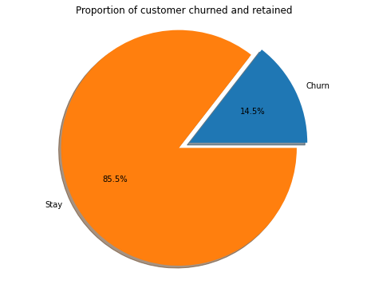

```python
#default churn rate
labels = 'Churn', "Stay"
sizes = [df.Churn[df['Churn'] == 1].count(), df.Churn[df['Churn'] == 0].count()]
explode = (0.1, 0)

fig1, ax1 = plt.subplots(figsize=(8, 6))
ax1.pie(sizes, explode=explode, labels=labels, autopct='%1.1f%%', shadow=True)
ax1.axis('equal')

plt.title("Proportion of customer churned and retained")

plt.show()
```

```python
#Let's look at the relationship between variables

#preperation
df_hue = df.copy()
df_hue["Churn"] = np.where(df_hue["Churn"] == 0, "S", "C")
df_new = df_hue[["Churn","AccountWeeks", "DataUsage", "CustServCalls", "DayMins", "DayCalls", "MonthlyCharge", "OverageFee", "RoamMins"]]
```

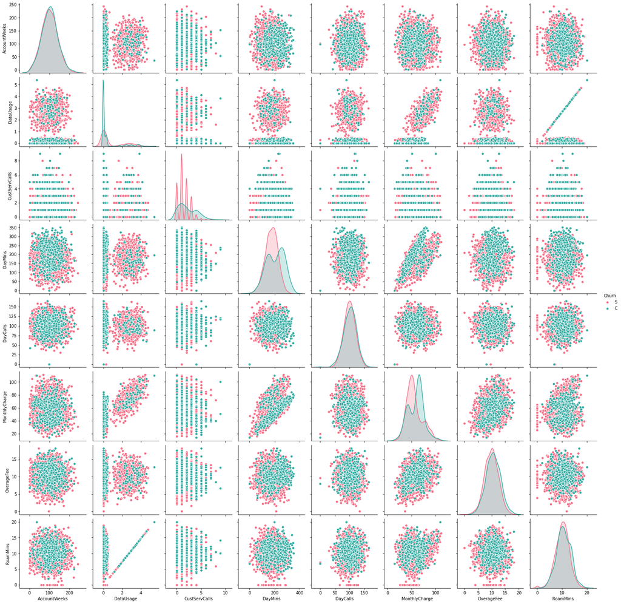

```python
#A master view at all the numerical variables
sns.pairplot(df_new, hue="Churn", palette="husl")
```

Noticeable things from density graph:

- **Daysmins** and **MonthlyCharge** would be helpful for us to seperate the groups. Maybe I can look into what might relate to them so that I can amplify the difference during feature engineering.
- Group *"Churned"* has a disporpotionally high **DataUsage** of 0. It is hard to see why it is the case for now. However in generally DataUsage is highly skewed with lots of 0.
- For **CustomerServiceCalls**, group *"Stay"* is as likely to make a call as Group *"Churn"* and the mode is around 2 calls. However, when it is more than 3 or 4 calls, it's mostly only Group *"Churn"*.

Noticeable things between two different variables:

- **DataUsage** has a linear relationship with **RoamMins** for the ones that are not 0. This needs further investigation to see if we can just use one of the variables.
- **MonthlyCharge** has a positive relationship with **DataUsage**, **DayMins** and **OverageFee**

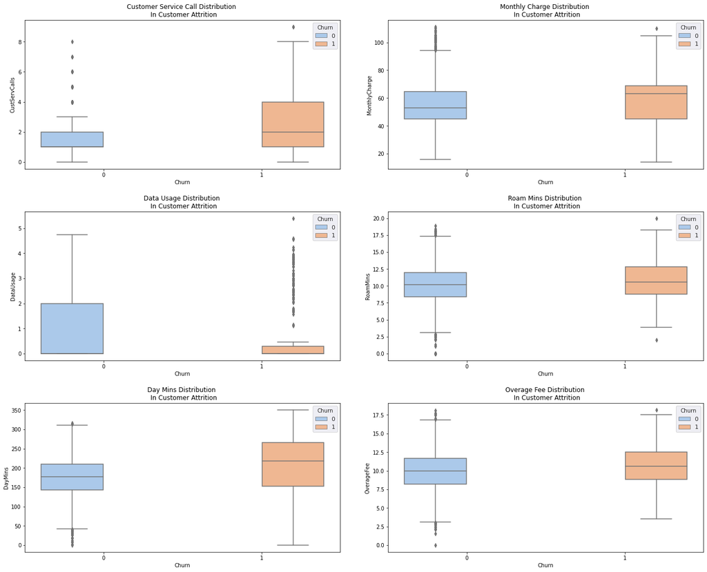

```python
# A closer look at the relations based on the continuous data attributes
fig, axarr = plt.subplots(3, 2, figsize=(20, 16))
fig.tight_layout(pad=6.0) #space between subplots

sns.set(palette='pastel',) #setting the color/style of our plots

sns.boxplot(y="CustServCalls", x="Churn", hue = "Churn", data=df, ax=axarr[0][0]).set_title("Customer Service Call Distribution \n In Customer Attrition")
sns.boxplot(y="MonthlyCharge", x="Churn", hue = "Churn", data=df, ax=axarr[0][1]).set_title("Monthly Charge Distribution \n In Customer Attrition")
sns.boxplot(y="DataUsage", x="Churn", hue = "Churn", data=df, ax=axarr[1][0]).set_title("\nData Usage Distribution \n In Customer Attrition")
sns.boxplot(y='RoamMins', x="Churn", hue = "Churn", data=df, ax=axarr[1][1]).set_title("\nRoam Mins Distribution \n In Customer Attrition")
sns.boxplot(y="DayMins", x="Churn", hue = "Churn", data=df, ax=axarr[2][0]).set_title("\nDay Mins Distribution \n In Customer Attrition")
sns.boxplot(y="OverageFee", x="Churn", hue = "Churn", data=df, ax=axarr[2][1]).set_title("Overage Fee Distribution \n In Customer Attrition")
```

Noticiable thing from the boxplot:

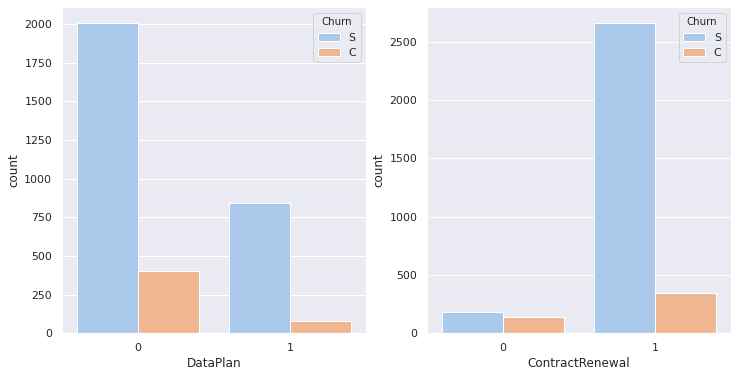

```python
#Let's quickly look at the histogram of categorical varaibles
fig, axarr = plt.subplots(1, 2, figsize=(12, 6))
sns.countplot(x='DataPlan', hue = 'Churn',data = df_hue, ax=axarr[0], palette="pastel")
sns.countplot(x='ContractRenewal', hue = 'Churn',data = df_hue, ax=axarr[1], palette="pastel")
```

Noticeable things from histogram:

- The two variables are highly skewed. Majority of the samples in Group *"no data plan"* but *with contract renewal* recently.
- In Group *"no data plan"*, the propotion of Group *"Churn"* is higher than in group *"with data plan"*.
- For ContractRenewal, Group *"no contract renewal"*, propotion of Group *"Churn"* is significantly higher compare to the propotion in Group "with contract renewal".
- I wonder how the samples were collected. The different behaviors in the two groups can be actual difference but can also be due to incomplete data collection.

Connecting to the previous analysis:

- I think why we have lots of 0 in dataUsage was because we have lots of customers in Group *"no data plan"*.

```python
#Let's do a quick check to see if all the 0 in DataUsage is due to the O in DataPlan
#in percentage
nousage_perce = (len(df[df["DataUsage"]==0])/len(df))*100
noplan_perce = (len(df[df["DataPlan"]==0])/len(df)) *100
print("The percentage for people with 0 data usage is " + str(round(nousage_perce, 2)) + " percent")
print("The percentage for people with no data plan is " + str(round(noplan_perce, 2)) + " percent")

#in absolute number
nousage = len(df[df["DataUsage"]==0])
noplan = len(df[df["DataPlan"]==0])
print(str(nousage) + " numbers of people have 0 data usage.")
print(str(noplan) + " numbers of people have 0 data plan.")
print("\nInsight: 598 people who did not purchase a data plan were also using data. Let's check the roaming data.")

#for the people who didn't have a data plan but still have data usage, to they belong to roaming?
#Roaming info
roam = len(df[df["RoamMins"]!=0])
print("\n" + str(roam) + " numbers of people used roaming.")
print("\nInsight: Seems like almost everyone uses Roaming and it does not relates to wheather you use data.")
```

```
The percentage for people with 0 data usage is 54.4 percent
The percentage for people with no data plan is 72.34 percent
1813 numbers of people have 0 data usage.
2411 numbers of people have 0 data plan.

Insight: 598 people who did not purchase a data plan were also using data. Let's check the roaming data.

3315 numbers of people used roaming.

Insight: Seems like almost everyone uses Roaming and it does not relates to wheather you use data.
```

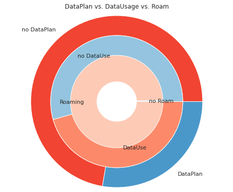

```python
#using a pie chart to visualize the relationship between the three variables

group_names=['no DataPlan', 'DataPlan']
group_size=[2411, (3333-2411)]

subgroup1_names=['no DataUse','DataUse']
subgroup1_size=[1813, (3333-1813)]

subgroup2_names=['no Roam', 'Roaming']
subgroup2_size=[(3333-3315), 3315]

# Create colors
a, b, c=[plt.cm.Blues, plt.cm.Reds, plt.cm.Greens]

# First Ring (Outside)
fig, ax = plt.subplots(figsize=(8, 6))
ax.axis('equal')
mypie, _ = ax.pie(group_size, radius=1.3, labels=group_names, colors=[b(0.6), a(0.6)])
plt.setp( mypie, width=0.3, edgecolor='white')

# Second Ring (Inside)
mypie2, _ = ax.pie(subgroup1_size, radius=1.3-0.3, labels=subgroup1_names, labeldistance=0.7, colors=[a(0.4), b(0.4)])
plt.setp( mypie2, width=0.4, edgecolor='white')
plt.margins(0,0)

# Third Ring (Most Inner)
mypie3, _ = ax.pie(subgroup2_size, radius=1.3-0.3-0.3, labels=subgroup2_names, labeldistance=0.7, colors=[a(0.2), b(0.2)])
plt.setp( mypie3, width=0.4, edgecolor='white')
plt.margins(0,0)

# show it
ax.set(title='DataPlan vs. DataUsage vs. Roam\n')
plt.show()
```

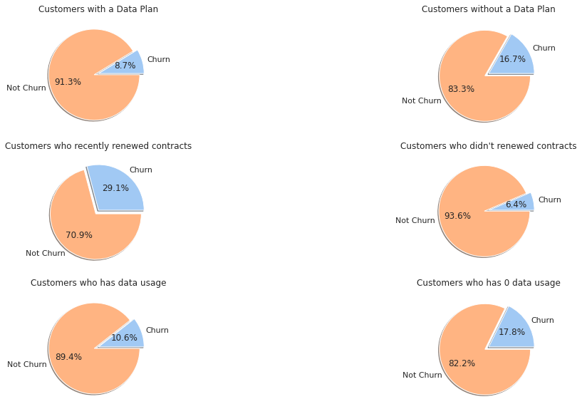

```python
#categorical variables exploration

fig, axs = plt.subplots(3, 2, figsize=(18,10))
explode = (0, 0.1)
labels=['Churn', 'Not Churn']

#data plan
has_plan=[len(df[(df["DataPlan"]==1) & (df["Churn"]==1)]), len(df[(df["DataPlan"]==1) & (df["Churn"]==0)])]
axs[0, 0].pie(has_plan, explode=explode, labels=labels, autopct='%1.1f%%', shadow=True)
axs[0, 0].set_title("Customers with a Data Plan")

no_plan = [len(df[(df["DataPlan"]==0) & (df["Churn"]==1)]), len(df[(df["DataPlan"]==0) & (df["Churn"]==0)])]
axs[0, 1].pie(no_plan, explode=explode, labels=labels, autopct='%1.1f%%', shadow=True)
axs[0, 1].set_title("Customers without a Data Plan")

#Contract Renewal
has_ContractRenewal=[len(df[(df["ContractRenewal"]==1) & (df["Churn"]==1)]), len(df[(df["DataPlan"]==1) & (df["Churn"]==0)])]
axs[1, 0].pie(has_ContractRenewal, explode=explode, labels=labels, autopct='%1.1f%%', shadow=True)
axs[1, 0].set_title("Customers who recently renewed contracts")

no_ContractRenewal = [len(df[(df["ContractRenewal"]==0) & (df["Churn"]==1)]), len(df[(df["DataPlan"]==0) & (df["Churn"]==0)])]
axs[1, 1].pie(no_ContractRenewal, explode=explode, labels=labels, autopct='%1.1f%%', shadow=True)
axs[1, 1].set_title("Customers who didn't renewed contracts")

#Datausage
has_Datausage=[len(df[(df["DataUsage"]!=0) & (df["Churn"]==1)]), len(df[(df["DataUsage"]!=0) & (df["Churn"]==0)])]
axs[2, 0].pie(has_Datausage, explode=explode, labels=labels, autopct='%1.1f%%', shadow=True)
axs[2, 0].set_title("Customers who has data usage")

no_Datausage = [len(df[(df["DataUsage"]==0) & (df["Churn"]==1)]), len(df[(df["DataUsage"]==0) & (df["Churn"]==0)])]
axs[2, 1].pie(no_Datausage, explode=explode, labels=labels, autopct='%1.1f%%', shadow=True)
axs[2, 1].set_title("Customers who has 0 data usage")

plt.show()
```

# 4. Feature Engineering

```python
df_model = df.copy()
```

```python
#To investigate why churn rate is so different between group "Have Dataplan" and "No Dataplan". I create a new variable, peopel who didn't have a data plan but still used data
df_model["data_w_noplan"]=np.where((df_model["DataPlan"]==0) & (df_model["DataUsage"]!=0), 1, 0)
```

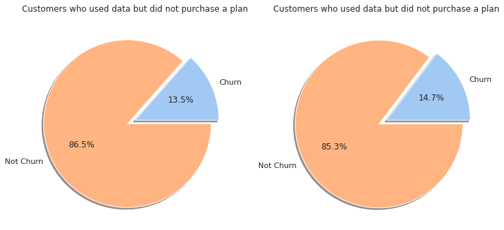

```python
#let's see if it is useful for our prediction
fig, ax = plt.subplots(1, 2, figsize = (12, 6))
data_w_noplan = [len(df_model[(df_model["data_w_noplan"]==1) & (df_model["Churn"]==1)]), len(df_model[(df_model["data_w_noplan"]==1) & (df_model["Churn"]==0)])]
ax[0].pie(data_w_noplan, explode=explode, labels=labels, autopct='%1.1f%%', shadow=True)
ax[0].set_title("Customers who used data but did not purchase a plan")

data_w_plan = [len(df_model[(df_model["data_w_noplan"]==0) & (df_model["Churn"]==1)]), len(df_model[(df_model["data_w_noplan"]==0) & (df_model["Churn"]==0)])]
ax[1].pie(data_w_plan, explode=explode, labels=labels, autopct='%1.1f%%', shadow=True)
ax[1].set_title("Customers who used data but did not purchase a plan")
```

```python
#it was useless. Let's drop that.
df_model.drop(['data_w_noplan'], axis = 1)
```

|  | Churn | AccountWeeks | ContractRenewal | DataPlan | DataUsage | CustServCalls | DayMins | DayCalls | MonthlyCharge | OverageFee | RoamMins |
| --- | --- | --- | --- | --- | --- | --- | --- | --- | --- | --- | --- |
| 0 | 0 | 128 | 1 | 1 | 2.70 | 1 | 265.1 | 110 | 89.0 | 9.87 | 10.0 |
| 1 | 0 | 107 | 1 | 1 | 3.70 | 1 | 161.6 | 123 | 82.0 | 9.78 | 13.7 |
| 2 | 0 | 137 | 1 | 0 | 0.00 | 0 | 243.4 | 114 | 52.0 | 6.06 | 12.2 |
| 3 | 0 | 84 | 0 | 0 | 0.00 | 2 | 299.4 | 71 | 57.0 | 3.10 | 6.6 |
| 4 | 0 | 75 | 0 | 0 | 0.00 | 3 | 166.7 | 113 | 41.0 | 7.42 | 10.1 |
| ... | ... | ... | ... | ... | ... | ... | ... | ... | ... | ... | ... |
| 3328 | 0 | 192 | 1 | 1 | 2.67 | 2 | 156.2 | 77 | 71.7 | 10.78 | 9.9 |
| 3329 | 0 | 68 | 1 | 0 | 0.34 | 3 | 231.1 | 57 | 56.4 | 7.67 | 9.6 |
| 3330 | 0 | 28 | 1 | 0 | 0.00 | 2 | 180.8 | 109 | 56.0 | 14.44 | 14.1 |
| 3331 | 0 | 184 | 0 | 0 | 0.00 | 2 | 213.8 | 105 | 50.0 | 7.98 | 5.0 |
| 3332 | 0 | 74 | 1 | 1 | 3.70 | 0 | 234.4 | 113 | 100.0 | 13.30 | 13.7 |

3333 rows × 11 columns

```python
#Let's see if it relates to still using a roaming service while didn't purchase a data plan.
df_model["roam_w_noplan"]=np.where((df_model["DataPlan"]==0) & (df_model["RoamMins"]!=0), 1, 0)
```

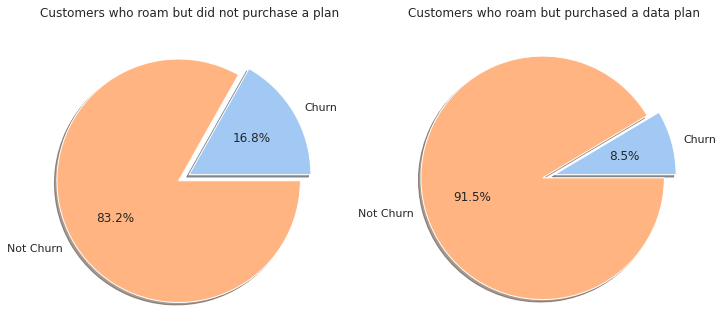

```python
fig, ax = plt.subplots(1, 2, figsize = (12, 6))
roam_w_noplan = [len(df_model[(df_model["roam_w_noplan"]==1) & (df_model["Churn"]==1)]), len(df_model[(df_model["roam_w_noplan"]==1) & (df_model["Churn"]==0)])]
ax[0].pie(roam_w_noplan, explode=explode, labels=labels, autopct='%1.1f%%', shadow=True)
ax[0].set_title("Customers who roam but did not purchase a plan")

roam_w_plan = [len(df_model[(df_model["roam_w_noplan"]==0) & (df_model["Churn"]==1)]), len(df_model[(df_model["roam_w_noplan"]==0) & (df_model["Churn"]==0)])]
ax[1].pie(roam_w_plan, explode=explode, labels=labels, autopct='%1.1f%%', shadow=True)
ax[1].set_title("Customers who roam but purchased a data plan")

#people who doesn't have a data plan and churn were more likely due to the fact that they still use the roaming service.
```

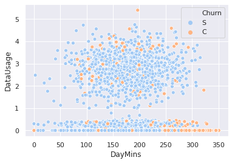

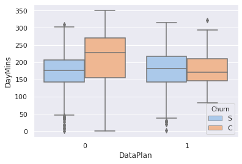

```python
#let's see if people with 0 data usage uses calls more often
sns.scatterplot(x='DayMins', y="DataUsage", hue = 'Churn', data = df_hue, palette="pastel")
#Seems like it is not that people with low data usage will call more often but that people who doesn't have data usage and still have make lots of calls are very likely to be churn. However, 0 data usage are mostly due to wheather they have a data plan or not.

#relationship between dataplan and Daymins
fig = plt.subplots()
sns.boxplot(x='DataPlan', y="DayMins", hue = 'Churn', data = df_hue, palette="pastel")
```

On Average, people who didn't purchase a data plan and uses lots of minutes are very likely to be churn.

```python
#For people who didn't purchase a data plan. I squared the data so that I amplify the affect of havnig lots of call minutes.
df_model["DayMins_noplan"]=np.where((df_model["DataPlan"]==0) & (df_model["DayMins"]!=0), df_model.DayMins**2, df_model.DayMins**2)
```

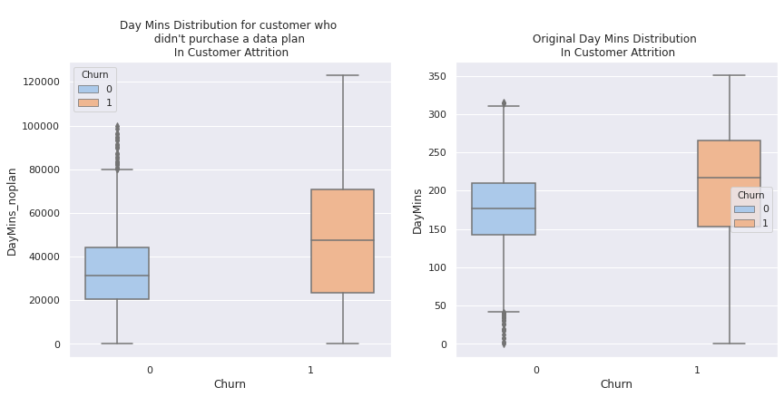

```python
fig, ax = plt.subplots(1, 2, figsize = (14, 6))
sns.boxplot(y="DayMins_noplan", x="Churn", hue = "Churn", ax=ax[0], data=df_model).set_title("\nDay Mins Distribution for customer who \n didn't purchase a data plan \n In Customer Attrition")
sns.boxplot(y="DayMins", x="Churn", hue = "Churn", ax=ax[1], data=df).set_title("\nOriginal Day Mins Distribution \n In Customer Attrition")
#Let's see if it helps with the model
```

# 5. Basic Model fitting with original data

```python
from sklearn.model_selection import train_test_split, GridSearchCV, StratifiedKFold
from sklearn.model_selection import cross_val_score

from sklearn.dummy import DummyClassifier
from sklearn.tree import DecisionTreeClassifier
from sklearn.ensemble import RandomForestClassifier
from sklearn.ensemble import GradientBoostingClassifier
from xgboost import XGBClassifier

from sklearn.metrics import accuracy_score, confusion_matrix, classification_report
from sklearn.metrics import precision_recall_curve, auc, roc_curve
```

```python
#dat preperation
label = df["Churn"]
df_train1 = df.iloc[:, 1:].copy()
feature_names = list(df_train1.columns.values)

#I seperate the data into train, valiation and test. We will reserve the test set till the end to test the performance of the best model.

#set, testset
X_trainval, X_test, y_trainval, y_test = train_test_split(df_train1, label, test_size = 0.2, random_state=1)
#train, validation set split
X_train, X_val, y_train, y_val = train_test_split(X_trainval, y_trainval, test_size = 0.2, random_state=1)
```

### Baseline Model

```python
#dummy model
dummy1 = DummyClassifier(random_state=1).fit(X_train, y_train)
pred_dummy1 = dummy1.predict(X_val)
print("randomly guessing score: {:.2f}".format(dummy1.score(X_val,y_val)))
dummy2 = DummyClassifier(strategy = 'most_frequent').fit(X_train, y_train)
pred_dummy2 = dummy2.predict(X_val)
print("guess all customers will stay score: {:.2f}".format(dummy2.score(X_val,y_val)))
```

```
randomly guessing score: 0.73
guess all customers will stay score: 0.85
```

### Different Tree models

```python
#tree model
tree = DecisionTreeClassifier(random_state=1).fit(X_train, y_train)
print("Decision Tree validation score: {:.2f}".format(tree.score(X_val, y_val)))
tree_crossval = cross_val_score(tree, X_trainval, y_trainval)
print("Decision Tree cross-validation score: {:.2f}".format(tree_crossval.mean()))

#tree model with simple tune
tree_tune = DecisionTreeClassifier(random_state=1, max_depth = 6).fit(X_train, y_train)
#I picked 6 by just trying out different numbers. We can also use GridSearchCV to select the best parameters but I am a bit lazy to do so.
print("Decision Tree validation score after tune: {:.2f}".format(tree_tune.score(X_val, y_val)))
pred_tree = tree.predict(X_val)
tree_crossval_tune = cross_val_score(tree_tune, X_trainval, y_trainval)
print("Decision Tree cross-validation score (tune): {:.2f}".format(tree_crossval_tune.mean()))

print("\nFeature Importantce ranking "+ str(sorted(zip(map(lambda x: round(x, 4), tree.feature_importances_), feature_names),
             reverse=True)))
```

```
Decision Tree validation score: 0.90
Decision Tree cross-validation score: 0.89
Decision Tree validation score after tune: 0.92
Decision Tree cross-validation score (tune): 0.92

Feature Importantce ranking [(0.1928, 'DayMins'), (0.1429, 'OverageFee'), (0.1345, 'CustServCalls'), (0.1266, 'MonthlyCharge'), (0.1197, 'RoamMins'), (0.0878, 'DataUsage'), (0.0819, 'ContractRenewal'), (0.0561, 'DayCalls'), (0.0558, 'AccountWeeks'), (0.0019, 'DataPlan')]
```

```python
#random forest model
forest = RandomForestClassifier(random_state=1, max_depth=8).fit(X_train, y_train)
pred_forest = forest.predict(X_val)
print("Random Forest validation score: {:.2f}".format(forest.score(X_val, y_val)))
forest_crossval = cross_val_score(forest, X_trainval, y_trainval)
print("Random Forest cross-validation score: {:.2f}".format(forest_crossval.mean()))

#find important features
print("\nFeature Importantce ranking "+ str(sorted(zip(map(lambda x: round(x, 4), forest.feature_importances_), feature_names),
             reverse=True)))
```

```
Random Forest validation score: 0.93
Random Forest cross-validation score: 0.94

Feature Importantce ranking [(0.2089, 'DayMins'), (0.174, 'MonthlyCharge'), (0.166, 'CustServCalls'), (0.0903, 'ContractRenewal'), (0.0818, 'OverageFee'), (0.0789, 'RoamMins'), (0.0768, 'DataUsage'), (0.0462, 'DayCalls'), (0.0394, 'AccountWeeks'), (0.0377, 'DataPlan')]
```

```python
#Gradient Boosting model
gradient = GradientBoostingClassifier(random_state=1).fit(X_train, y_train)
pred_gradient = gradient.predict(X_val)
#print("Gradient Boosting train score: {:.2f}".format(gradient.score(X_train, y_train)))
print("Gradient Boosting validation score: {:.2f}".format(gradient.score(X_val, y_val)))
gradient_crossval = cross_val_score(gradient, X_trainval, y_trainval)
print("Grandient Boosting cross-validation score: {:.2f}".format(gradient_crossval.mean()))
```

```
Gradient Boosting validation score: 0.93
Grandient Boosting cross-validation score: 0.93
```

```python
#XG bossting model
xg = XGBClassifier().fit(X_train, y_train)
pred_xg = xg.predict(X_val)
#print("XGBoost train score: {:.2f}".format(xg.score(X_train, y_train)))
print("XGBoost validation score: {:.2f}".format(xg.score(X_val, y_val)))
xg_crossval = cross_val_score(xg, X_trainval, y_trainval)
print("XGBoost cross-validation score: {:.2f}".format(xg_crossval.mean()))
```

```
XGBoost validation score: 0.92
XGBoost cross-validation score: 0.93
```

# 6. Basic model Evaluation

```python
#confusion matrix for dummy
confusion_dummy = confusion_matrix(y_val, pred_dummy2)
print("confusion matrix for dummy model:\n{}".format(confusion_dummy))

#confusion matrix for random forest. I picked RF because it was the most accurate model from the aboved analysis.
confusion_forest=confusion_matrix(y_val, pred_forest)
print("confusion matrix for random forest:\n{}".format(confusion_forest))
```

```
confusion matrix for dummy model:
[[452   0]
 [ 82   0]]
confusion matrix for random forest:
[[445   7]
 [ 30  52]]
```

Based on the confusion matrix, the our RF model makes more False Negative mistakes, which means customers will churn but the model says it will stay. It is because we have so many "Stay" in the sample that the model is focusing on getting the "Stay" class right, not the "Churn" class. We will need to rebalance the dataset.

```python
#classification_report
#dummy
print("dummy classificatoin report\n")
print(classification_report(y_val, pred_dummy2, target_names = ["Stay", "Churn"]))
print("\nrandom forest classification report\n")
print(classification_report(y_val, pred_forest, target_names = ["Stay", "Churn"]))
```

```
dummy classificatoin report

              precision    recall  f1-score   support

        Stay       0.85      1.00      0.92       452
       Churn       0.00      0.00      0.00        82

    accuracy                           0.85       534
   macro avg       0.42      0.50      0.46       534
weighted avg       0.72      0.85      0.78       534


random forest classification report

              precision    recall  f1-score   support

        Stay       0.94      0.98      0.96       452
       Churn       0.88      0.63      0.74        82

    accuracy                           0.93       534
   macro avg       0.91      0.81      0.85       534
weighted avg       0.93      0.93      0.93       534
```

From the classification report aboved, the difference between the model's ability to predict "Stay" vs. to predict "Churn is even more obvious. Here are some reminders what "precision" and "recall" are:

- Precision: True Positive / (True Positive + False Positive). Let's translate to Englis and let's use the example of "Churn", which is 0.88. It means: The times the model rightly predicted customers will churn / (rightly predict churn + predict churn but the client stay) is 88%
- Recall: True Positive / (True Positive + False Negative). Let's translate to Englis and let's use the example of "Churn", which is 0.63. It means: The times the model rightly predicted customers will churn / (rightly predict churn + predict stay but the client churn) is 63%

# 7. downsample to rebalance dataset

```python
from sklearn.utils import resample
```

```python
# Separate majority and minority classes
df_maj = df[df.Churn==0]
df_min = df[df.Churn==1]

print("The minority sample size is: {}".format(len(df_min))) #483

# Downsample majority class
df_maj_ds = resample(df_maj, replace=False,    # sample without replacement
                             n_samples=483,     # to match minority class
                             random_state=1) # reproducible results
# Combine minority class with downsampled majority class
df_ds = pd.concat([df_maj_ds, df_min])

# Display new class counts
df_ds.Churn.value_counts()
```

```
The minority sample size is: 483
```

```
1    483
0    483
Name: Churn, dtype: int64
```

```python
#dat preperation
label2 = df_ds["Churn"]
df_ds_train = df_ds.iloc[:, 1:].copy()
feature_names2 = list(df_ds_train.columns.values)
#set, testset split
Xds_train, Xds_val, yds_train, yds_val = train_test_split(df_ds_train, label2, test_size = 0.2, random_state=1)
```

```python
#tree after downsample
tree_ds = DecisionTreeClassifier(random_state=1, max_depth = 6).fit(Xds_train, yds_train)
print("Random Forest validation score: {:.2f}".format(tree_ds.score(Xds_val, yds_val)))
tree_ds_crossval = cross_val_score(tree_ds, Xds_val, yds_val)
print("Random Forest cross-validation score: {:.2f}".format(tree_ds_crossval.mean()))
print("\nFeature Importantce ranking "+ str(sorted(zip(map(lambda x: round(x, 4), tree_ds.feature_importances_), feature_names2),
             reverse=True)))
```

```
Random Forest validation score: 0.85
Random Forest cross-validation score: 0.84

Feature Importantce ranking [(0.2686, 'DayMins'), (0.2237, 'ContractRenewal'), (0.2109, 'CustServCalls'), (0.1632, 'OverageFee'), (0.0424, 'DataUsage'), (0.0358, 'RoamMins'), (0.0255, 'DayCalls'), (0.0186, 'MonthlyCharge'), (0.0112, 'AccountWeeks'), (0.0, 'DataPlan')]
```

```python
#random forest model after downsampled
forest_ds = RandomForestClassifier(random_state=1).fit(Xds_train, yds_train)
print("Random Forest validation score: {:.2f}".format(forest_ds.score(Xds_val, yds_val)))
forest_ds_crossval = cross_val_score(forest_ds, Xds_val, yds_val)
print("Random Forest cross-validation score: {:.2f}".format(forest_ds_crossval.mean()))
print("\nFeature Importantce ranking "+ str(sorted(zip(map(lambda x: round(x, 4), forest_ds.feature_importances_), feature_names2),
             reverse=True)))

#confusion matrix for random forest downsampled
pred_forest_ds = forest_ds.predict(X_val)
confusion_forest_ds=confusion_matrix(y_val, pred_forest_ds)
print("\nconfusion matrix:\n{}".format(confusion_forest_ds))

#classification_report
print("\nrandom forest classification report after downsampled\n")
print(classification_report(y_val, pred_forest_ds, target_names = ["Stay", "Churn"]))
```

```
Random Forest validation score: 0.89
Random Forest cross-validation score: 0.87

Feature Importantce ranking [(0.1897, 'DayMins'), (0.1722, 'CustServCalls'), (0.1494, 'MonthlyCharge'), (0.1029, 'OverageFee'), (0.1009, 'ContractRenewal'), (0.0769, 'RoamMins'), (0.0659, 'DayCalls'), (0.0589, 'AccountWeeks'), (0.0588, 'DataUsage'), (0.0245, 'DataPlan')]

confusion matrix:
[[414  38]
 [  2  80]]

random forest classification report after downsampled

              precision    recall  f1-score   support

        Stay       1.00      0.92      0.95       452
       Churn       0.68      0.98      0.80        82

    accuracy                           0.93       534
   macro avg       0.84      0.95      0.88       534
weighted avg       0.95      0.93      0.93       534
```

The overall accuracy decreased. However, our recall rate greatly increased! This is what we want because our goal is to identify people who will churn so that we can do something about it. Now, with a great recall rate, let's see if we can improve the overall accuracy rate further.

- We will first look at how our model will perform with newly added feature.
- Then we will pick the best model to look at precision vs. recall curve to tune it.

# 8. model with added features

```python
# balance that dataset first

# Separate majority and minority classes
df_maj2 = df_model[df_model.Churn==0]
df_min2 = df_model[df_model.Churn==1]

print("The minority sample size is: {}".format(len(df_min2))) #483

# Downsample majority class
df_maj2_ds = resample(df_maj2, replace=False,    # sample without replacement
                             n_samples=483,     # to match minority class
                             random_state=1) # reproducible results
# Combine minority class with downsampled majority class
df_ds2 = pd.concat([df_maj2_ds, df_min2])

# Display new class counts
df_ds2.Churn.value_counts()
```

```
The minority sample size is: 483
```

```
1    483
0    483
Name: Churn, dtype: int64
```

```python
#data preperation
label3 = df_ds2["Churn"]
df_ds_train2 = df_ds2.iloc[:, 1:].copy()
feature_names3 = list(df_ds_train2.columns.values)
#set, testset split
Xds_train2, Xds_val2, yds_train2, yds_val2 = train_test_split(df_ds_train2, label3, test_size = 0.2, random_state=1)
```

```python
#tree after feature engineering
tree_ds2 = DecisionTreeClassifier(random_state=1, max_depth = 6).fit(Xds_train2, yds_train2)
print("Tree validation score: {:.2f}".format(tree_ds2.score(Xds_val2, yds_val2)))
tree_ds_crossval2 = cross_val_score(tree_ds2, Xds_val2, yds_val2)
print("Tree cross-validation score: {:.2f}".format(tree_ds_crossval2.mean()))
print("\nFeature Importantce ranking "+ str(sorted(zip(map(lambda x: round(x, 4), tree_ds2.feature_importances_), feature_names3),
             reverse=True)))
```

[output not shown]

```python
#random forest model after downsampled
forest_ds2 = RandomForestClassifier(random_state=1).fit(Xds_train2, yds_train2)
print("Random Forest validation score: {:.2f}".format(forest_ds2.score(Xds_val2, yds_val2)))
forest_ds_crossval2 = cross_val_score(forest_ds2, Xds_val2, yds_val2)
print("Random Forest cross-validation score: {:.2f}".format(forest_ds_crossval2.mean()))
print("\nFeature Importantce ranking "+ str(sorted(zip(map(lambda x: round(x, 4), forest_ds2.feature_importances_), feature_names3),
             reverse=True)))

#confusion matrix for random forest downsampled
pred_forest_ds2 = forest_ds2.predict(Xds_val2)
confusion_forest_ds2=confusion_matrix(yds_val2, pred_forest_ds2)
print("\nconfusion matrix:\n{}".format(confusion_forest_ds2))

#classification_report
print("\nrandom forest classification report after downsampled\n")
print(classification_report(yds_val2, pred_forest_ds2, target_names = ["Stay", "Churn"]))
```

[output not shown]

So, actually the newly created features didn't help at all. Let's go with the original model.

# 9. precision vs. recall curve

The ability to predict Group "Churn" accurately improved a lot after we balance the dataset. However, let's see the precision-recall to see if we are at the optimal tradeoff point.

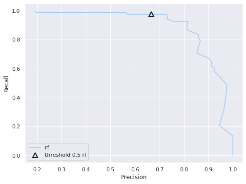

```python
fig= plt.subplots(figsize=(8, 6))
precision_rf, recall_rf, thresholds_rf = precision_recall_curve(y_val, forest_ds.predict_proba(X_val)[:, 1])
plt.plot(precision_rf, recall_rf, label="rf")

close_default_rf = np.argmin(np.abs(thresholds_rf - 0.5))
plt.plot(precision_rf[close_default_rf], recall_rf[close_default_rf], '^', c='k', markersize=10, label='threshold 0.5 rf', fillstyle="none", mew=2)
plt.xlabel("Precision")
plt.ylabel("Recall")
plt.legend(loc="best")
```

Looks like we can maintain the same recall rate and improve the overall accuracy with an adjustment of the rate of threshold.

```python
threshold = 0.56 #after different trails, this is the best

predicted_proba = forest_ds.predict_proba(X_val)
predicted = (predicted_proba [:,1] >= threshold).astype('int')

#compare the accuracy scores
accuracy_adj = accuracy_score(y_val, predicted)
print("accurcy rate with 0.56 threshold {}".format(str(round(accuracy_adj,4,)*100))+"%")

accuracy = accuracy_score(y_val, pred_forest_ds)
print("accurcy rate with 0.5 threshold {}".format(str(round(accuracy,4,)*100))+"%")

#confusion matrix compare
confusion_forest=confusion_matrix(y_val, predicted)
print("confusion matrix with new threshold:\n{}".format(confusion_forest))

pred_forest_ds = forest_ds.predict(X_val)
confusion_forest_ds=confusion_matrix(y_val, pred_forest_ds)
print("\nconfusion matrix original:\n{}".format(confusion_forest_ds))

#classification_report
print("\nrandom forest classification report with adjuested threshold\n")
print(classification_report(y_val, predicted, target_names = ["Stay", "Churn"]))
```

```
accurcy rate with 0.56 threshold 94.01%
accurcy rate with 0.5 threshold 92.51%
confusion matrix with new threshold:
[[422  30]
 [  2  80]]

confusion matrix original:
[[414  38]
 [  2  80]]

random forest classification report with adjuested threshold

              precision    recall  f1-score   support

        Stay       1.00      0.93      0.96       452
       Churn       0.73      0.98      0.83        82

    accuracy                           0.94       534
   macro avg       0.86      0.95      0.90       534
weighted avg       0.95      0.94      0.94       534
```

### Accuracy rate vs. real business cost

```python
threshold = 0.85

predicted_proba = forest_ds.predict_proba(X_val)
predicted2 = (predicted_proba [:,1] >= threshold).astype('int')

#compare the accuracy scores
accuracy_adj2 = accuracy_score(y_val, predicted2)
print("accurcy rate with 0.56 threshold is {}".format(str(round(accuracy_adj,4,)*100))+"%")
print("accurcy rate with 0.85 threshold is {}".format(str(round(accuracy_adj2,4,)*100))+"%")
```

```
accurcy rate with 0.56 threshold is 94.01%
accurcy rate with 0.85 threshold is 95.32000000000001%
```

```python
tn, fp, fn, tp = confusion_matrix(y_val, predicted).ravel()
tn_aj, fp_aj, fn_aj, tp_aj = confusion_matrix(y_val, predicted2).ravel()

#assume we have 4000 customers per month
lost_1 = (fn/(tn+fp+tp))*4000
lost_2 = (fn_aj/(tn_aj+fp_aj+tp_aj))*4000
print("With a lower accuracy model, we will miss "+str(math.ceil(lost_1))+" customers who will change their phone plans.")
print("With a higher accuracy model, we will miss "+str(math.ceil(lost_2))+" customers who will change their phone plans.")
```

```
With a lower accuracy model, we will miss 16 customers who will change their phone plans.
With a higher accuracy model, we will miss 108 customers who will change their phone plans.
```

# 10. final test

```python
print("Random Forest final test score: {:.2f}".format(forest_ds.score(X_test, y_test)))
test_crossval = cross_val_score(forest_ds, df_train1, label)
print("Random Forest final cross-validation test score: {:.2f}".format(test_crossval.mean()))

test_forest = forest_ds.predict(X_test)
confusion_test=confusion_matrix(y_test, test_forest)
print("\nconfusion matrix:\n{}".format(confusion_test))

test_proba = forest_ds.predict_proba(X_test)

test = (test_proba [:,1] >= 0.56).astype('int')

accuracy_test = accuracy_score(y_test, test)
#test_crossval2 = cross_val_score(test, df_train1, label)
print("\naccurcy rate with test data with 0.56 threshold is {}".format(str(round(accuracy_test,4,)*100))+"%")
#print("cross-validation rate with test data is {}".format(str(round(test_crossval2,4,)*100))+"%")

print("\nrandom forest classification report with adjuested threshold\n")
print(classification_report(y_test, test, target_names = ["Stay", "Churn"]))
```

```
Random Forest final test score: 0.90
Random Forest final cross-validation test score: 0.94

confusion matrix:
[[507  62]
 [  2  96]]

accurcy rate with test data with 0.56 threshold is 91.75%

random forest classification report with adjuested threshold

              precision    recall  f1-score   support

        Stay       1.00      0.91      0.95       569
       Churn       0.64      0.98      0.78        98

    accuracy                           0.92       667
   macro avg       0.82      0.94      0.86       667
weighted avg       0.94      0.92      0.92       667
```

# Additional: Business Insights

### How useful is our model?

```python
test_dummy = dummy2.predict(X_test)

tn_dummy, fp_dummy, fn_dummy, tp_dummy = confusion_matrix(y_test,test_dummy).ravel()

tn_test, fp_test, fn_test, tp_test = confusion_matrix(y_test, test).ravel()

#assume we have 4000 customers per month
lost_dummy = (fn_dummy/(tn_dummy+fp_dummy+tp_dummy))*4000
lost_model = (fn_test/(tn_test+fp_test+tp_test))*4000
print("Assume we have 4000 customers per month, with random guessing, we will miss "+str(math.ceil(lost_dummy))+" customers who will change their phone plans.")
print("Assume we have 4000 customers per month, with the final model, we will miss "+str(math.ceil(lost_model))+" customers who will change their phone plans.")
```

```
Assume we have 4000 customers per month, with random guessing, we will miss 689 customers who will change their phone plans.
Assume we have 4000 customers per month, with the final model, we will miss 13 customers who will change their phone plans.
```

### What type of customers are most likely to churn? Why?

From the aboved analysis, customers with higher monthly bills are more likely to churn, especially for people who use calling service alot. The group that is most likely to churn are

- customers who did not purchase a data plan, but still use our roaming service.
- customers who did not purchase a data plan and still using our calling service aboved the average.

### Advice?

- Provide some plan or package for the call service so that people who need to use lots of minutes (above 200-250 mins) can purchase some plans and will not result in a very costly monthly bill.
- Consider providing different options for our roaming service too. Over 90% of the customers use our roaming servcie and for those who didn't purchase a data plan, they have a high churn rate. So, consider lowering those people's bill.